### Sea Cucumber Differential Gene Expression Data of Intestine Regenrative Tissue

**Joshua Medina** | 7/16/2019

### Overview

The sea cucumber *Holothuria glaberrima* has great regenerative capability after internal organs evisceration. In this case, we are analyzing data from mesentery regenerative tissue of 1 and 3 days post evisceration (1- and 3-DPE) in order to further understand the genes that are involved in the early stages of regeneration.

#### Process

Set the directory to work in and load required libraries.

```r
setwd("~/git/DEdq2019/")

suppressMessages(library(DESeq2))
suppressMessages(library(gplots))
suppressMessages(library(RColorBrewer))
suppressMessages(library(EnhancedVolcano))
suppressMessages(library(tidyverse))
```

**Loading the data.**

- The variable *names* will contain the genenames or in this case the ID given by the assembler for all the reads in the count data to be used.
- The variable *ddata* contains a csv file indicating the files to be used and to which group they correspond (i.e experimental or control). In our case this is going to consist of three different levels normal, 1 day post-evisceration (1DPE), and 3 days post-evisceration (3DPE).

```r
names <- read.table("data/genenames.txt", header=FALSE, row.names = 1)
ddata <- read.csv("data/ddata.csv", header = TRUE)
```

Generating the data set with respect to the counts.

```r
ddsSTAR <- DESeqDataSetFromHTSeqCount(sampleTable = ddata, directory = "data/countsmay2019", design = ~ condition)

colData(ddsSTAR)$condition <- factor(colData(ddsSTAR)$condition, levels=levels(ddata$condition))

#set a factor variable with six levels (conditions of the study).
#Totally needed another option is to use relevel.
```

Estimating the size factors using *“median ratio method”*, dispersions (gene-wise, mean-dispersion relationship, final dispersion estimates). Generating the counts table with *counts* function.

```r
dds <- estimateSizeFactors(ddsSTAR)
dds <- estimateDispersions(dds)
dds <- nbinomWaldTest(dds)
counts_table <- counts(dds, normalized=TRUE)
```

```r
res_3DPE <- results(dds, contrast = c("condition", "3DPE", "Control"))
res_3DPE <- res_3DPE[order(res_3DPE$padj),]

write.csv(as.data.frame(res_3DPE), file="data/dqData2019_3DPE.csv")
```

#### Visualization of the results.

Plotting dispersion estimates.

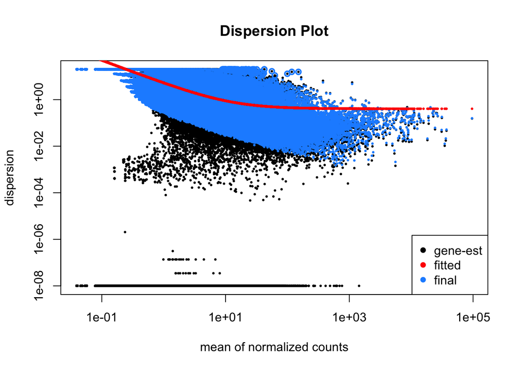

```r
DESeq2::plotDispEsts(dds,main="Dispersion Plot")
```

Raw Data vs normalized counts.

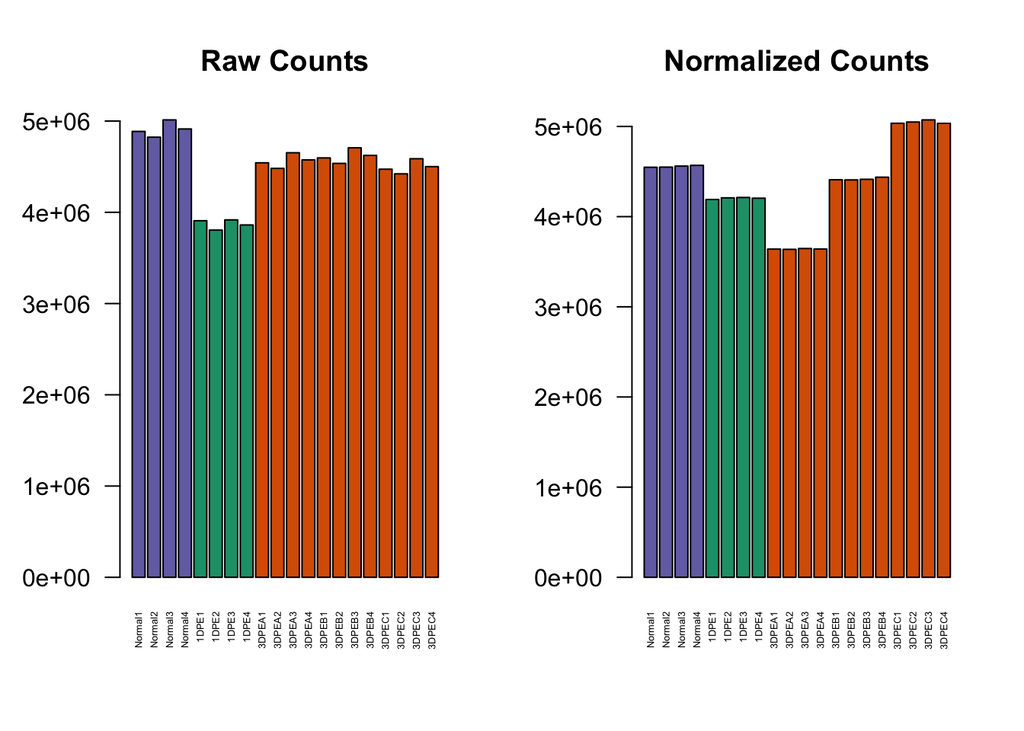

```r
conds <- as.vector(ddata$condition)
condcols <- brewer.pal(n = length(unique(conds)), name="Dark2")
par(mfrow=c(1,2))
barplot(colSums(counts(dds, normalized=F)), col = condcols[as.factor(conds)], las = 2, cex.names=0.4, main="Raw Counts")
barplot(colSums(counts(dds, normalized=T)), col=condcols[as.factor(conds)], las=2, cex.names = 0.4, main = "Normalized Counts")
```

```r
#is normalizing really a good thing for this data?
```

PCA Plot

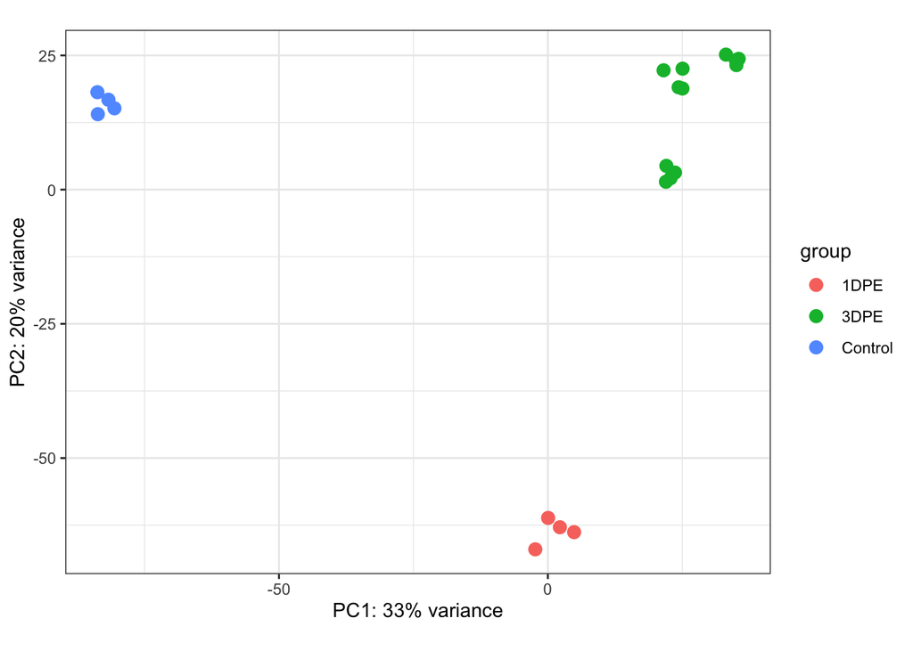

```r
vsd <- varianceStabilizingTransformation(dds)
DESeq2::plotPCA(vsd)+theme_bw()
```

Volcano Plot

Particularly, we are going to label Wnt family genes found in our data. Below we added a list of the specific Wnt name and its assembly ID.

- Wnt1 = ‘TRINITY_DN11077_c0_g1_i1’
- Wnt2 = ‘TRINITY_DN84401_c0_g1_i1’
- Wnt3 = ‘TRINITY_DN61112_c0_g1_i5’
- Wnt4 = ‘TRINITY_DN56808_c0_g1_i1’
- Wnt5 = ‘TRINITY_DN61053_c0_g1_i1’
- Wnt6 = ‘TRINITY_DN57277_c0_g3_i1’
- Wnt7 = ‘TRINITY_DN41286_c0_g1_i1’
- Wnt9 = ‘TRINITY_DN62364_c3_g3_i2’
- Wnt16 = ‘TRINITY_DN7204_c0_g1_i1’
- WntA = ‘TRINITY_DN24635_c0_g1_i1’
- WntA2 = ‘TRINITY_DN2998_c0_g1_i1’

```r
#Shape Override

#WntGenes <- c('TRINITY_DN11077_c0_g1_i1', 'TRINITY_DN84401_c0_g1_i1',
#              'TRINITY_DN61112_c0_g1_i5', 'TRINITY_DN56808_c0_g1_i1',
#              'TRINITY_DN61053_c0_g1_i1', 'TRINITY_DN57277_c0_g3_i1',
#              'TRINITY_DN41286_c0_g1_i1', 'TRINITY_DN62364_c3_g3_i2',
#              'TRINITY_DN7204_c0_g1_i1', 'TRINITY_DN24635_c0_g1_i1',
#              'TRINITY_DN2998_c0_g1_i1')

#keyvals.shape <- rep(3, nrow(res_3DPE))

#names(keyvals.shape) <- rep('All', nrow(res_3DPE))

#keyvals.shape[which(rownames(res_3DPE) %in% WntGenes)] <- 17
#names(keyvals.shape)[which(rownames(res_3DPE) %in% WntGenes)] <- 'Wnt Genes'

#unique(names(keyvals.shape))

#COLOR OVERRIDE
keyvals <- rep("black", nrow(res_3DPE))

names(keyvals) <- rep('Mid', nrow(res_3DPE))

keyvals[which(res_3DPE$log2FoldChange > 2.0)] <- 'royalblue'
names(keyvals)[which(res_3DPE$log2FoldChange > 2.0)] <- 'high'

keyvals[which(res_3DPE$log2FoldChange < -2.0)] <- 'red'
names(keyvals)[which(res_3DPE$log2FoldChange < -2.0)] <- 'low'
```

Removing duplicates from keyvals.

```r
unique(names(keyvals))
```

```
## [1] "low"  "high" "Mid"
```

```r
unique(keyvals)
```

```
## [1] "red"       "royalblue" "black"
```

```r
head(keyvals)
```

```
##         low         low         low         low         low        high
##       "red"       "red"       "red"       "red"       "red" "royalblue"
```

```r
tail(keyvals)
```

```
##     Mid     Mid     Mid     low     Mid     Mid
## "black" "black" "black"   "red" "black" "black"
```

The actual plot…

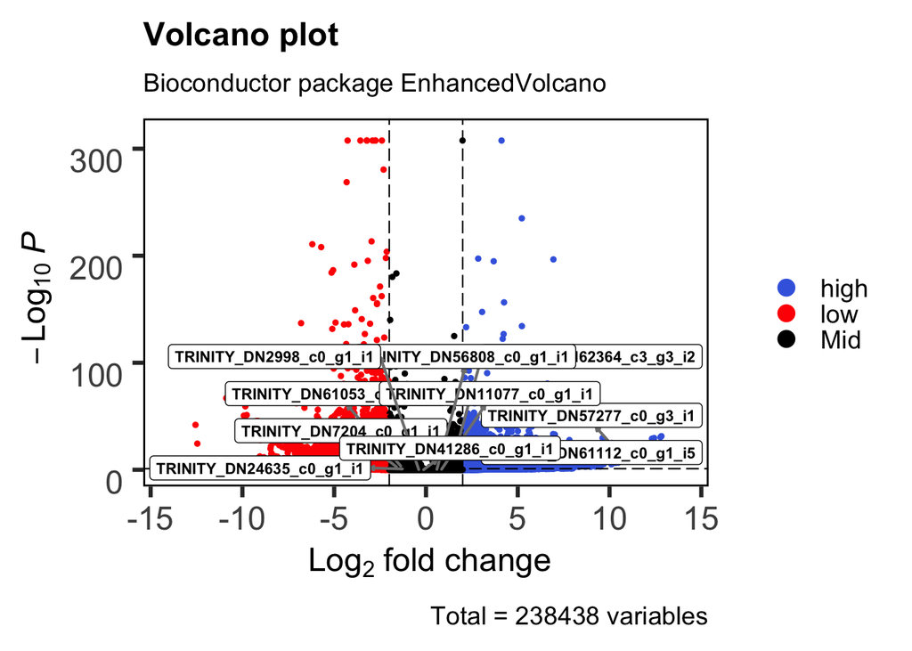

```r
EnhancedVolcano(res_3DPE,
                lab = rownames(res_3DPE),
                x = 'log2FoldChange',
                y = 'padj',
                selectLab = c('TRINITY_DN11077_c0_g1_i1', 'TRINITY_DN84401_c0_g1_i1',
              'TRINITY_DN61112_c0_g1_i5', 'TRINITY_DN56808_c0_g1_i1',
              'TRINITY_DN61053_c0_g1_i1', 'TRINITY_DN57277_c0_g3_i1',
              'TRINITY_DN41286_c0_g1_i1', 'TRINITY_DN62364_c3_g3_i2',
              'TRINITY_DN7204_c0_g1_i1', 'TRINITY_DN24635_c0_g1_i1',
              'TRINITY_DN2998_c0_g1_i1'),
                xlim = c(-14,14),
                xlab = bquote(~Log[2]~ 'fold change'),
                pCutoff = 10e-2,
                FCcutoff = 2.0,
                transcriptPointSize = 1.0,
                transcriptLabSize = 3.0,
                transcriptLabCol = 'black',
                transcriptLabFace = 'bold',
                boxedlabels = TRUE,
                colCustom = keyvals,
                colAlpha = 1,
                legendPosition = 'right',
                legendLabSize = 14,
                legendIconSize = 4.0,
                drawConnectors = TRUE,
                widthConnectors = 0.75,
                colConnectors = 'grey50',
                gridlines.major = FALSE,
                gridlines.minor = FALSE,
                border = 'full',
                borderWidth = 1.0,
                borderColour = 'black')
```

Heatmap of all Wnt family genes…

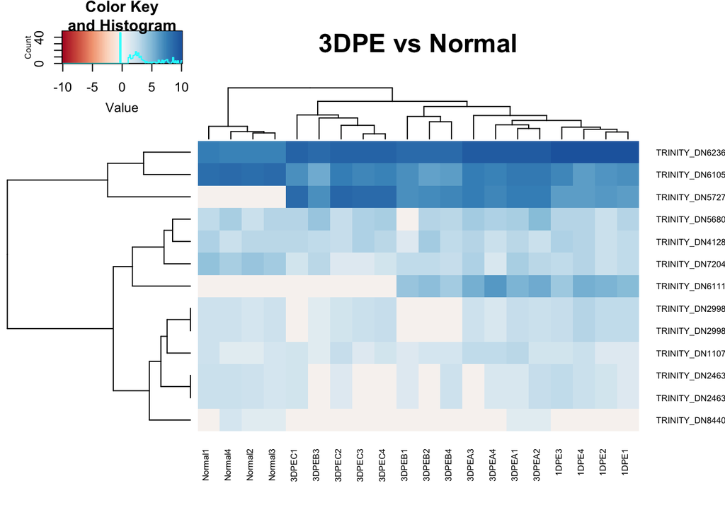

```r
hmcol <- colorRampPalette(brewer.pal(9, "RdBu"))(100)

#hits_3DPEvsNORM <- rownames(res_3DPE[(res_3DPE$padj <= 0.001) & (!is.na(res_3DPE$padj)) & (abs(res_3DPE$log2FoldChange) >= 2),])
#hits_3DPEvsNORM2 <- hits_3DPEvsNORM[1:100]
#heatmap.2(assay(vsd[hits_3DPEvsNORM2,]), trace="none", col=hmcol, cexRow = 0.2, cexCol = 0.6, las=2, Colv=TRUE, dendogram="row", key=TRUE, main="3DPE vs Normal")
heatmap.2(assay(vsd[c('TRINITY_DN24635_c0_g1_i1', 'TRINITY_DN2998_c0_g1_i1',
                      'TRINITY_DN11077_c0_g1_i1', 'TRINITY_DN84401_c0_g1_i1',
                      'TRINITY_DN61112_c0_g1_i5', 'TRINITY_DN56808_c0_g1_i1',
                      'TRINITY_DN61053_c0_g1_i1', 'TRINITY_DN57277_c0_g3_i1',
                      'TRINITY_DN41286_c0_g1_i1', 'TRINITY_DN62364_c3_g3_i2',
                      'TRINITY_DN7204_c0_g1_i1', 'TRINITY_DN24635_c0_g1_i1',
                      'TRINITY_DN2998_c0_g1_i1'),]), trace="none", col=hmcol, cexRow = 0.6, cexCol = 0.6, las=2,
          Colv=TRUE, dendogram="row", key=TRUE, main="3DPE vs Normal")
```